# Grappling with the “Daily Spiritual Experiences” scale

Last updated 2018-04-07

Here we look at the “daily spiritual experiences” scale (Underwood & Teresi; Packet 1) in detail.

**NOTE**: There were four on this scale (`dse_07`, `dse_08`, `dse_15`, and `dse_16`), where Thai participants answered a bunch of different questions instead of just one (these were questions dealing with multiple spiritual entities instead of just “God”). Here, we deal with this by “crediting” Thai participants with their *maximum* response for *any* of the options for that question (i.e., if they answered at the extreme negative end of the response scale for all but one question, and at the extreme positive end for one question, they’d get “credited” with the extreme positive response). For our current purposes, I have *not* kept track of which particular question this was.

# Differences across fieldsites

## Mean scores by site

First, let’s look at scores for Questions #1-14 for participants in each site (Tanya indicated that this was a separate subscale):

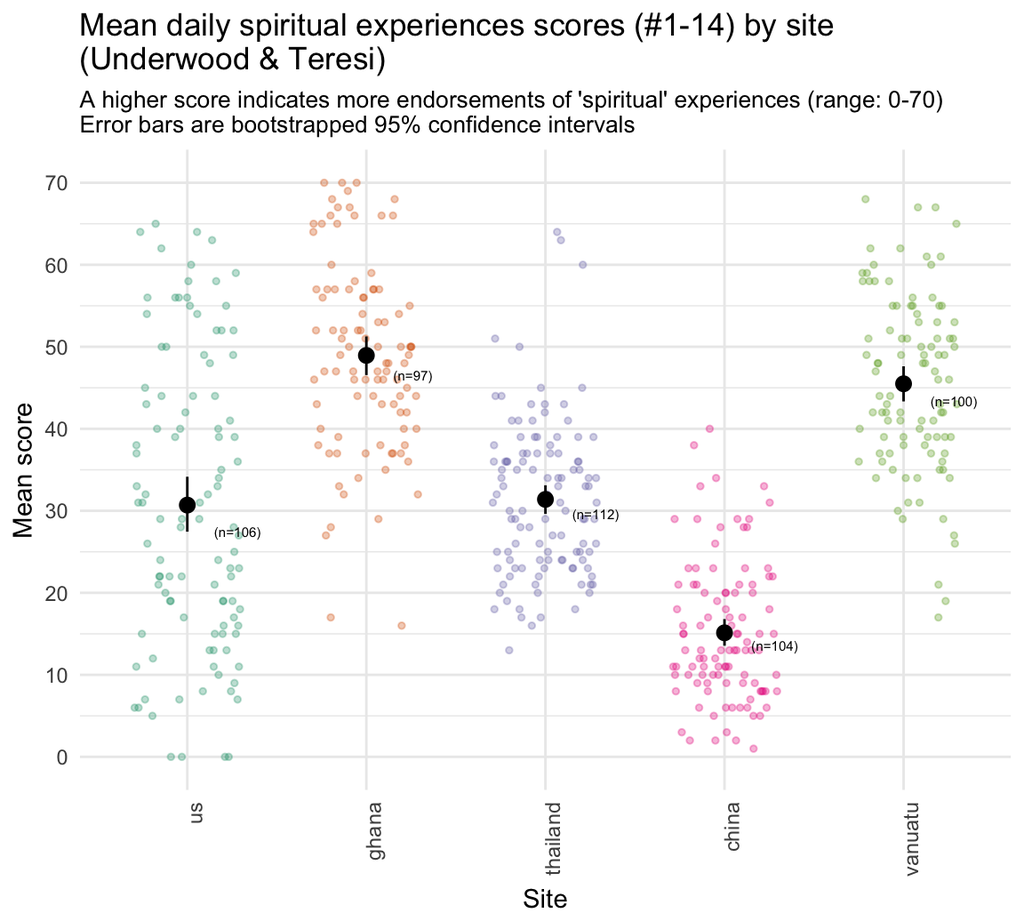

Note that this plot includes both average scores for each site (in black), and individual scores for all of the participants in that site (small, colorful points in the background, which are “jittered” around a little so that you can see them all).

Looks like people in different sites responded quite differently to this scale! As with the “spiritual events” scale (Luhrmann; see other doc), participants in Ghana and Vanuatu responded much more positively; participants in the US and Thailand look about the same to me, and participants in China here seem to have responded substantially more negatively.

Let’s also look at the “extra” items about closeness to God* (questions #15-16), in the aggregate:

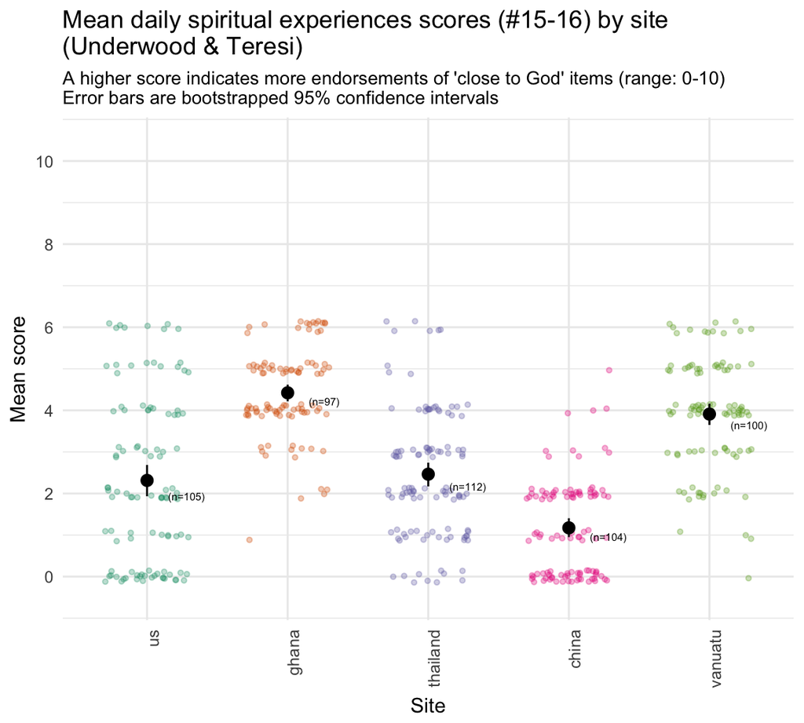

Again, this plot includes both average scores for each site (in black), and individual scores for all of the participants in that site (small, colorful points in the background, which are “jittered” around a little so that you can see them all).

Very similar pattern to what we saw above.

Now let’s look at these differences in more detail using the “raw data” for individual questions, rather than these subscale scores.

## Responses by question, by site

```
Column `question` joining character vector and factor, coercing into character vectorIgnoring unknown aesthetics: fill
```

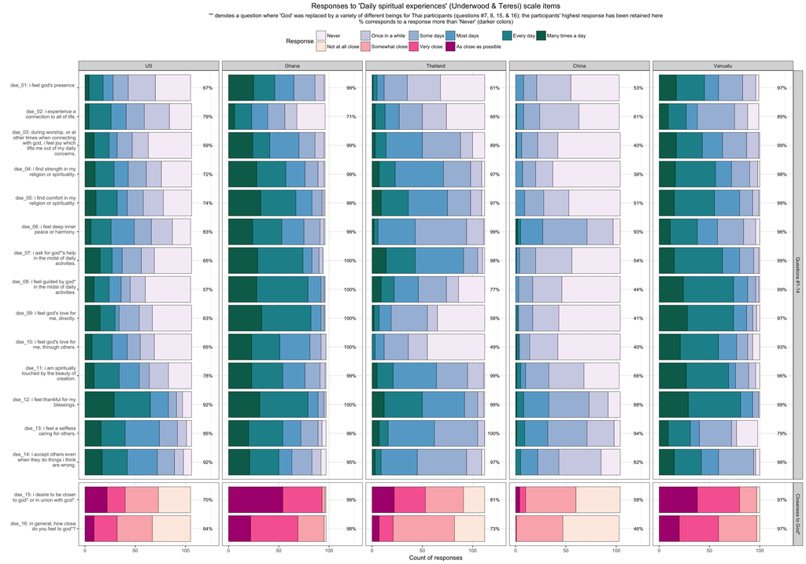

VERY eager to hear others’ observations… lots to chew on here. Off the top of my head, a few things stand out:

- Tons of positive responses in GH and VT, to almost every item. Troubling? Interesting? Both?
- Tons of negative responses in CH. Troubling? Interesting? Both?
- People may have used the response scale differently in different places (attention **Emily**, who raised this question!): e.g., people in CH almost never used the “Every day” or “Many times a day” extreme responses, while people GH and VT almost never used the “Never” extreme response.

This is just the tip of the iceberg. Tons to think through here.

# Distribution of responses for individual participants, by site

Another thing we might be interested in is how individual participants responded: Were there people who said yes to everything, or no to everything? How do these distributions of responses differ across participants in different sites?

Let’s take a look:

```
Column `question` joining character vector and factor, coercing into character vector
```

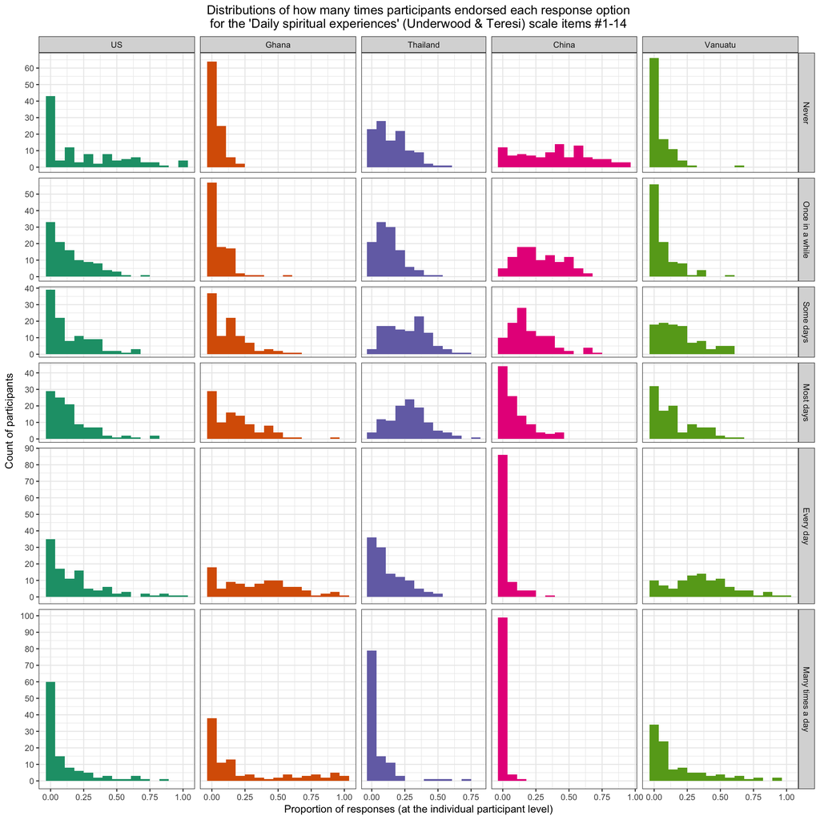

```
Column `question` joining character vector and factor, coercing into character vector
```

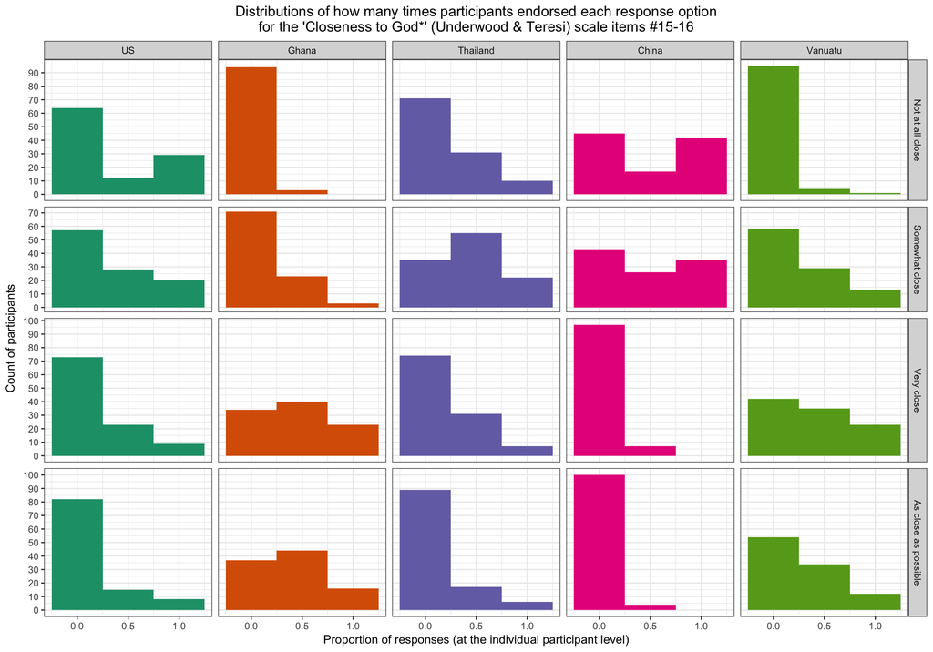

Again, lots to chew on here, and I haven’t taken a close look at any of this.

Just for fun, here’s another way to look at the same data, overlaying the density distributions for each site on top of each other to see where they seem to be similar/different:

```
Column `question` joining character vector and factor, coercing into character vector
```

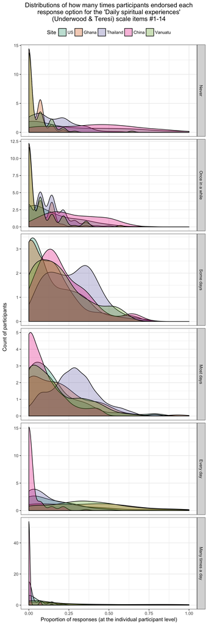

```
Column `question` joining character vector and factor, coercing into character vector
```

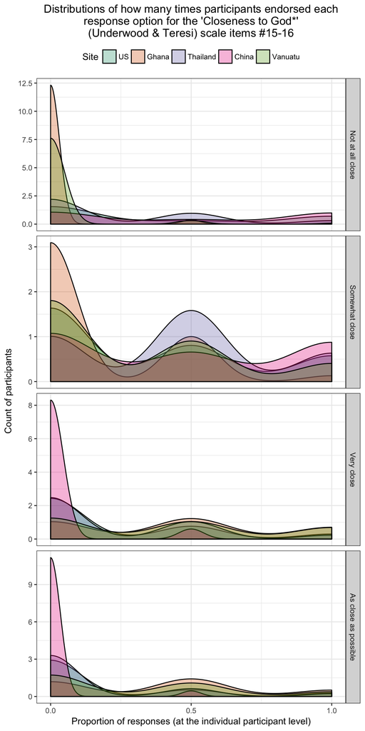